# 大五人格量表(BFI)嚴謹性趨勢分析

Kyle

2026-06-19

## 一、資料說明

本報告使用 psych 套件內建的 bfi 資料集，來自 International Personality Item Pool（IPIP），透過 SAPA 線上評估專案收集。本資料集共 2800 人，包含 25 題人格自評題項（1 = 非常不符合至 6 = 非常符合），涵蓋開放性（Openness）、嚴謹性（Conscientiousness）、外向性（Extraversion）、親和性（Agreeableness）、神經質（Neuroticism）五大維度，另有性別、教育程度、年齡三項人口統計變數。本報告聚焦於嚴謹性與性別及年齡之關聯。

## 二、遺漏值與異常值處理

```r
# 遺漏值檢查（輸出供報告文字參考）
bfi |>
  select(C1:C5, gender, age, education) |>
  summarise(across(everything(), ~sum(is.na(.))))
```

| C1 | C2 | C3 | C4 | C5 | gender | age | education |
| --- | --- | --- | --- | --- | --- | --- | --- |
| 21 | 24 | 20 | 26 | 16 | 0 | 0 | 223 |

```r
# C 題項遺漏值機制判斷
bfi |>
  mutate(missing_c = if_any(c(C1, C2, C3, C4, C5), is.na)) |>
  group_by(missing_c) |>
  summarise(
    n        = n(),
    mean_age = mean(age),
    sd_age   = sd(age),
    .groups  = "drop"
  )
```

| missing_c | n | mean_age | sd_age |
| --- | --- | --- | --- |
| FALSE | 2707 | 28.73291 | 11.07650 |
| TRUE | 93 | 30.21505 | 12.50465 |

```r
# 清理流程
bfi_clean <- bfi |>
  filter(!if_any(c(C1, C2, C3, C4, C5), is.na)) |>
  filter(age >= 11) |>
  mutate(
    C4r = 7 - C4,
    C5r = 7 - C5,
    conscientiousness = (C1 + C2 + C3 + C4r + C5r) / 5,
    gender = factor(gender, levels = c(1, 2), labels = c("男", "女"))
  )

# 年齡分組
bfi_clean <- bfi_clean |>
mutate(
  age_group = case_when(
    age <= 17 ~ "青少年",
    age <= 25 ~ "成年初顯期",
    age <= 39 ~ "成年期",
    TRUE      ~ "中年期"
  )
)

  bfi_clean$age_group <- factor(bfi_clean$age_group,
    levels = c("青少年", "成年初顯期", "成年期", "中年期"))
```

### 2.1 整體統計變數遺漏判斷

檢測統計變數遺漏值，發現教育程度中有 223 份遺漏值（8%）。進一步檢查教育程度與年齡的關聯，發現教育程度缺失的人平均年齡為 18 歲，有填的人平均年齡為 29.7 歲，差距相當大，強烈指向 MAR——年紀小的受試者尚未完成學業，無法對應「高中畢業／大學畢業／研究所」等選項。因教育程度並非本報告聚焦的關鍵變數，因此不予處理。

### 2.3 年齡異常值判斷

檢查年齡分布，發現最小值為 3 歲。排除 11 歲以下受試者共 2 人，因自評式人格量表需要形式運思能力方能有效作答。

### 2.4 反向計分

觀察題目內容，C4「半途而廢」與 C5「浪費時間」為低嚴謹性描述，進行反向計分（7 − 原始分數），使其與其他題項方向一致。五題平均後建立嚴謹性綜合分數。 清理後最終樣本為 2705 人。

## 三、描述統計表

```r
bfi_clean |>
  group_by(gender) |>
  summarise(
    n          = n(),
    mean   = mean(conscientiousness),
    sd     = sd(conscientiousness),
    median = median(conscientiousness),
    .groups    = "drop"
  ) |>
  knitr::kable(digits = 2, caption = "不同性別嚴謹性描述統計")
```

不同性別嚴謹性描述統計

| gender | n | mean | sd | median |
| --- | --- | --- | --- | --- |
| 男 | 887 | 4.14 | 0.97 | 4.2 |
| 女 | 1818 | 4.32 | 0.94 | 4.4 |

```r
bfi_clean |>
  group_by(age_group) |>
  summarise(
    n      = n(),
    mean   = mean(conscientiousness),
    sd     = sd(conscientiousness),
    median = median(conscientiousness),
    .groups    = "drop"
  ) |>
  knitr::kable(digits = 2, caption = "不同年齡組嚴謹性描述統計")
```

不同年齡組嚴謹性描述統計

| age_group | n | mean | sd | median |
| --- | --- | --- | --- | --- |
| 青少年 | 235 | 3.85 | 0.93 | 3.8 |
| 成年初顯期 | 1117 | 4.21 | 0.94 | 4.2 |
| 成年期 | 877 | 4.36 | 0.95 | 4.6 |
| 中年期 | 476 | 4.40 | 0.94 | 4.4 |

## 四、圖表

### 4.1 各年齡組嚴謹性分布

根據各年齡組的嚴謹性分數進行盒狀圖視覺化呈現。

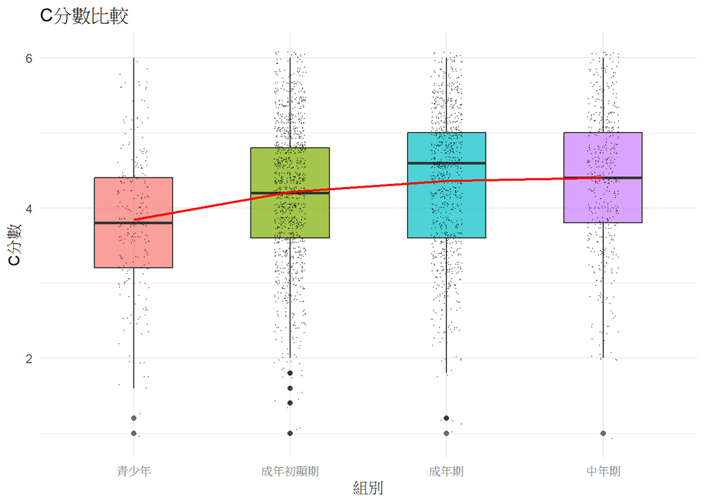

```r
ggplot(bfi_clean, aes(x=age_group, y=conscientiousness, fill=age_group)) +
  geom_boxplot(alpha=0.7, width=0.5) +
  geom_jitter(width=0.1, alpha=0.4, size=0.1) +
  stat_summary(fun = mean, geom = "line", aes(group = 1), linewidth = 0.8, color = 'red') +
  labs(title="C分數比較",
       x="組別", y="C分數") +
  theme_minimal() +
  theme(legend.position="none")
```

### 4.2 年齡與性別的連續趨勢

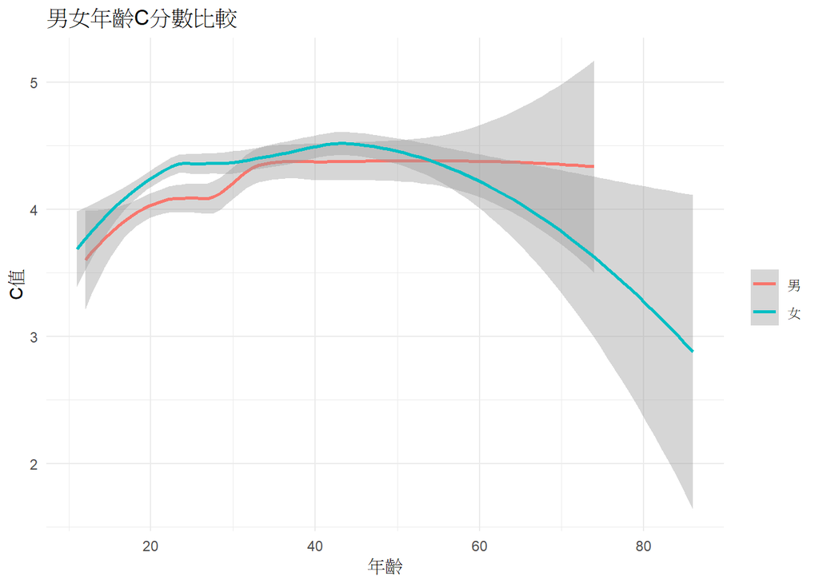

```r
ggplot(bfi_clean, aes(x = age, y = conscientiousness, color = gender)) +
  geom_smooth(method = "loess") +
  labs(title = "男女年齡C分數比較", x = "年齡", y = "C值", color = "") +
  theme_minimal()
```

### 4.3 題項層次比較

根據不同年齡組的嚴謹性各題分數進行折線圖視覺化呈現。

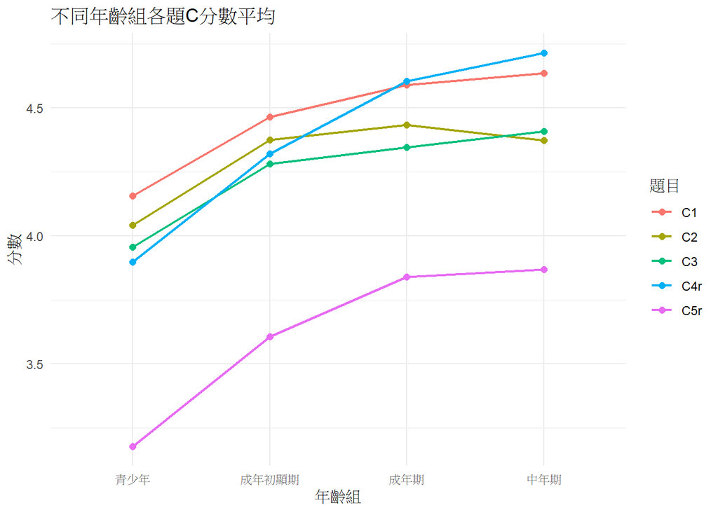

```r
bfi_long <- bfi_clean |>
  select(id = 1, age_group, C1, C2, C3, C4r, C5r) |>
  pivot_longer(cols = C1:C5r, names_to = "item", values_to = "score")

item_summary <- bfi_long |>
  group_by(age_group, item) |>
  summarise(mean = mean(score), .groups = "drop")

ggplot(item_summary, aes(x = age_group, y = mean, color = item, group = item)) +
  geom_line(linewidth = 0.8) +
  geom_point(size = 2) +
  labs(title = "不同年齡組各題C分數平均", x = "年齡組", y = "分數", color = "題目") +
  theme_minimal()
```

## 五、結果詮釋

整體來說，男性的嚴謹性平均分數（*M* = 4.14, *SD* = 0.97）略低於女性（*M* = 4.32, *SD* = 0.94），效果量極小（*d* = -.19）。

嚴謹性分數平均大致隨著年齡增高，青少年與中年期之間效果量中等（*d* = -.59）。55 歲以前，女性嚴謹性分數平均高於男性，而後有下滑趨勢，但因高齡樣本較少（45 歲以上男性 87 人、女性 216 人），此趨勢的推論應保持謹慎。

在題項層次上，第四題「半途而廢」隨年齡的變化最大（從 3.90 升至 4.72），第五題「不浪費時間」的分數則普遍低於其他題項，其餘分數隨年齡增長大致呈上升趨勢。